# PNMP

### 16. Thư viện matplotlib

#### Vẽ biểu đồ đơn giản

Ví dụ: Vẽ biểu đồ $$ y = x^2 $$

```python
#Ví dụ: vẽ biểu đồ y = x^2

import numpy as np # thư viện numpy
import matplotlib.pyplot as plt # thư viện pyplot
```

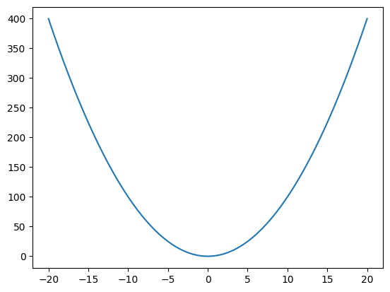

```python
# chia đoạn từ -20 đến 20 thành 1000 đoạn
x = np.linspace(-20, 20, 1000)
# tính y
y = x * x
# vẽ biểu đồ tương quan giữa x và y
plt.plot(x, y)
# hiển thị biểu đồ
plt.show()
```

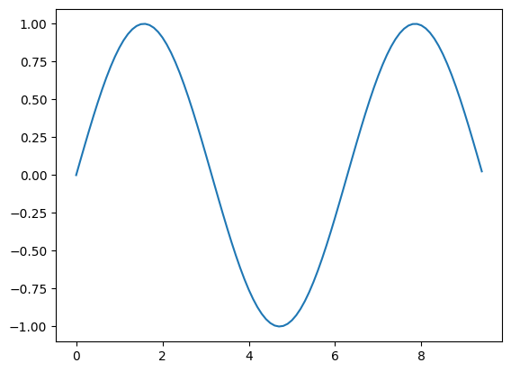

```python
# Vẽ biểu đồ hình sin
# chia đoạn từ 0 đến 3π thành các đoạn con 0.1
x = np.arange(0, 3 * np.pi, 0.1)
# tính sin tương ứng với từng phần tử của x
y = np.sin(x)
# vẽ biểu đồ tương quan giữa x và y
plt.plot(x, y)
# hiển thị biểu đồ
plt.show()
```

> Ví dụ: Biểu đồ cả SIN và COS

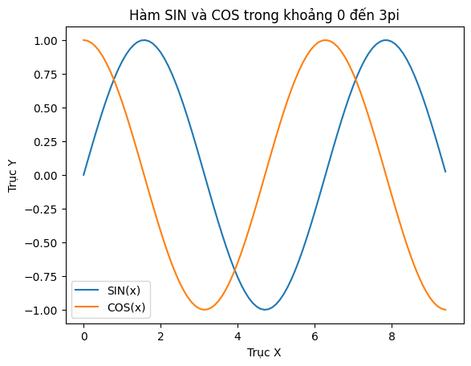

```python
x = np.arange(0, 3 * np.pi, 0.1)
y_sin = np.sin(x)
y_cos = np.cos(x)
plt.plot(x, y_sin)
plt.plot(x, y_cos)
plt.xlabel('Trục X')
plt.ylabel('Trục Y')
plt.title('Hàm SIN và COS trong khoảng 0 đến 3pi')
plt.legend(['SIN(x)', 'COS(x)'])
plt.show()
```

#### Một số loại biểu đồ thông dụng trong matplotlib

> Biểu đồ dạng đường (line plot)
- Biểu đồ thể hiện tương quan giữa X và Y
- **Cú pháp**: plot([x], y, [fmt], data=None, **kwargs) plot([x], y, [fmt], [x2], y2, [fmt2],..., **kwargs)
- **“fmt”** là quy cách vẽ đường
- **“data”** là nhãn của dữ liệu
- ****kwargs**: tham số vẽ đường
- Vẽ nhiều lần trên một biểu đồ
- Kết quả trả về là một list các đối tượng Line2D
- “fmt” gồm 3 phần fmt = '[color][marker][line]‘
- [color] – viết tắt tên màu:
  - `'b'` – blue
  - `'g'` – green
  - `'r'` – red
  - `'c'` – cyan
  - `'m'` – magenta
  - `'y'` – yellow
  - `'b'` – black
  - `'w'` – white
  - `#rrggbb` – chỉ ra mã màu theo hệ RGB
- [marker]
- cách đánh dấu dữ liệu:
  - `'o'` – hình tròn
  - `'v'` – tam giác xuống ('^', '<', '>')
  - `'*'` – ngôi sao
  - `'.'` – chấm
  - `'p'` – ngũ giác ...
- [line] – cách vẽ đường:
  - `'-'` – nét liền
  - `'--'` – nét đứt
  - `'-.'` – gạch chấm
  - `':'` – đường chấm

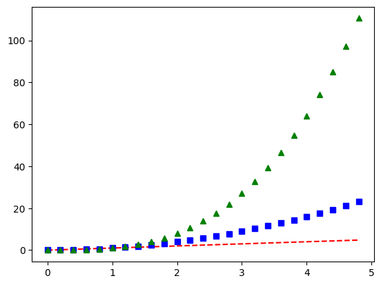

```python
# chia đoạn 0-5 thành các bước 0.2

t = np.arange(0., 5., 0.2)
# Vẽ 3 đường: #- màu đỏ nét đứt: y = x
# - màu xanh dương, đánh dấu ô vuông:
y = x*x #- màu xanh lá, đánh dấu tam giác:
y = x*x*x
plt.plot(t, t, 'r--', t, t**2, 'bs',
t, t**3, 'g^')
plt.show()
```

> Biểu đồ dạng cột (bar plot)
- Biểu đồ dạng cột chiều đứng

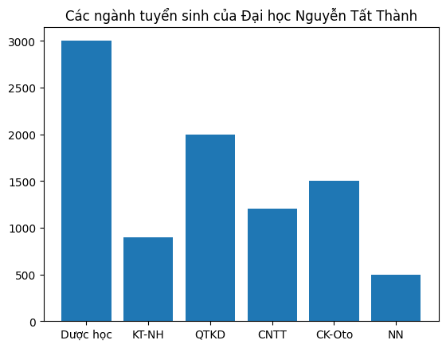

```python
D = { 'Dược học': 3000,
'KT-NH': 900,
'QTKD': 2000,
'CNTT': 1200,
'CK-Oto': 1500,
'NN': 500 }
plt.bar(range(len(D)), D.values(),
align='center')
plt.xticks(range(len(D)),
D.keys())
plt.title('Các ngành tuyển sinh của Đại học Nguyễn Tất Thành')
plt.show()
```

- Biểu đồ dạng cột chiều ngang

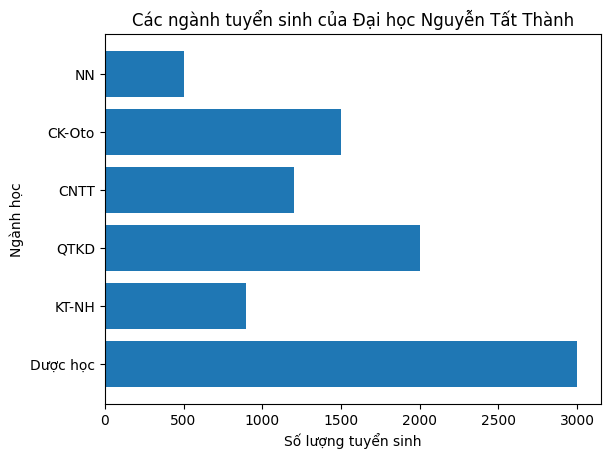

```python
D = {
    'Dược học': 3000,
    'KT-NH': 900,
    'QTKD': 2000,
    'CNTT': 1200,
    'CK-Oto': 1500,
    'NN': 500
}

plt.barh(range(len(D)), D.values(), align='center')
plt.yticks(range(len(D)), D.keys())
plt.title('Các ngành tuyển sinh của Đại học Nguyễn Tất Thành')
plt.xlabel('Số lượng tuyển sinh')
plt.ylabel('Ngành học')
plt.show()
```

- Ghép 2 biểu đồ

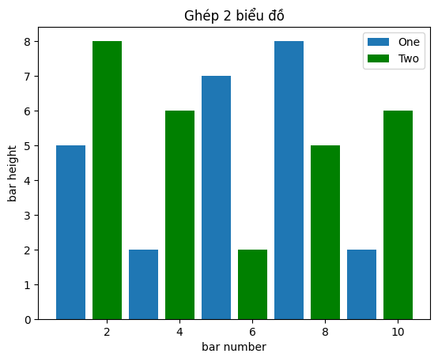

```python
plt.bar([1,3,5,7,9],[5,2,7,8,2], label="One")
plt.bar([2,4,6,8,10],[8,6,2,5,6], label="Two", color='g')
plt.legend()
plt.xlabel('bar number')
plt.ylabel('bar height')
plt.title('Ghép 2 biểu đồ')
plt.show()
```

> Biểu đồ bánh (pie chart)
- Làm rõ tương quan chi tiết / tổng thể

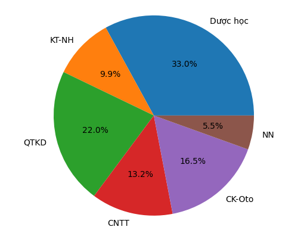

```python
D = { 'Dược học': 3000,
'KT-NH': 900,
'QTKD': 2000,
'CNTT': 1200,
'CK-Oto': 1500,
'NN': 500 }
plt.pie(D.values(),
labels=D.keys(), autopct='%1.1f%%')
plt.axis('equal') # trục x = trục y
plt.show()
```

> Một số chức năng hữu ích
- Chia thành các biểu đồ con

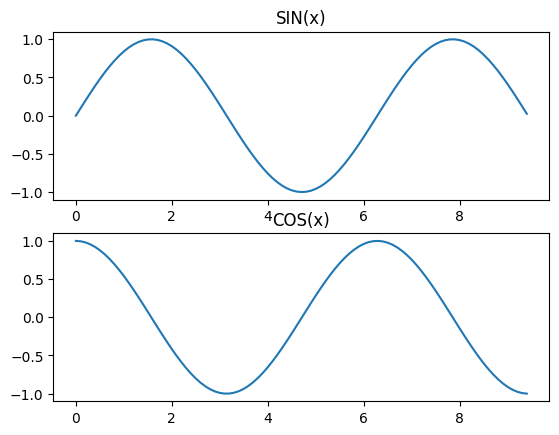

```python
x = np.arange(0, 3 * np.pi, 0.1)
y_sin = np.sin(x)
y_cos = np.cos(x)
plt.subplot(2, 1, 1) # biểu đồ 1
plt.plot(x, y_sin)
plt.title('SIN(x)')
plt.subplot(2, 1, 2) # biểu đồ 2
plt.plot(x, y_cos)
plt.title('COS(x)')
plt.show()
```

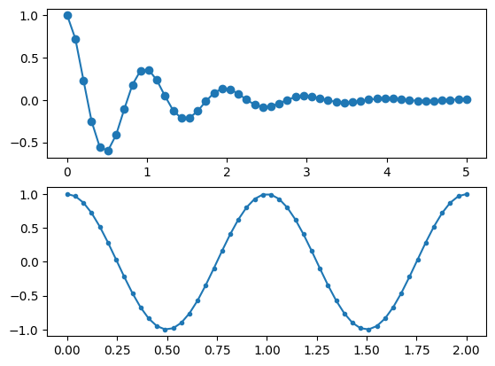

```python
# Một số biểu đồ khác
x1 = np.linspace(0.0, 5.0)
x2 = np.linspace(0.0, 2.0)
y1 = np.cos(2 * np.pi * x1) * np.exp(-x1)
y2 = np.cos(2 * np.pi * x2)
plt.subplot(2, 1, 1)
plt.plot(x1, y1, 'o-')
plt.subplot(2, 1, 2)
plt.plot(x2, y2, '.-')
plt.show()
```

- Nạp ảnh (png_jpg)

```python
import matplotlib.pyplot as plt
import matplotlib.image as mpimg
```

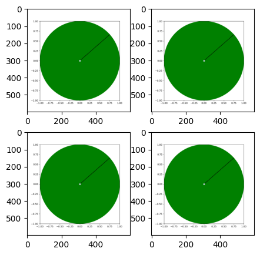

```python
image = mpimg.imread('pi.png')
fig, axs = plt.subplots(2, 2,figsize=(5, 5))
axs[0, 0].imshow(image)
axs[1, 0].imshow(image)
axs[0, 1].imshow(image)
axs[1, 1].imshow(image)
plt.show()
```

- lưu biểu đồ ra file

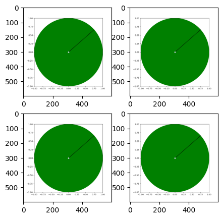

```python
image = mpimg.imread('pi.png')
fig, axs = plt.subplots(2, 2, figsize=(5, 5))
axs[0, 0].imshow(image)
axs[1, 0].imshow(image)
axs[0, 1].imshow(image)
axs[1, 1].imshow(image)

plt.savefig('1.jpg')
plt.savefig('1.pdf')
```

### 17. Thư viện Panda

#### 17.1. Làm việc với series

> Tạo dữ liệu series

```python
import pandas as pd
import numpy as np
```

```python
#Tạo dữ liệu series (1)
S = pd.Series(np.random.randint(100, size = 4))
print(S)
print(S.index)
print(S.values)
```

```
0    29
1    77
2    74
3    58
dtype: int64
RangeIndex(start=0, stop=4, step=1)
[29 77 74 58]
```

```python
#Tạo dữ liệu series (2)
chi_so = ["Ke toan", "KT", "CNTT", "Co khi"]
gia_tri = [310, 360, 580, 340]
S = pd.Series(gia_tri, index=chi_so)
print(S)
print(S.index)
print(S.values)
```

```
Ke toan    310
KT         360
CNTT       580
Co khi     340
dtype: int64
Index(['Ke toan', 'KT', 'CNTT', 'Co khi'], dtype='object')
[310 360 580 340]
```

```python
#Tạo dữ liệu series (3)
chi_so = ["KT", "KT", "CNTT", "Co khi"] # trùng nhau
gia_tri = [310, 360, 580, 340]
S = pd.Series(gia_tri, index=chi_so)
print(S)
print(S.index)
print(S.values)
```

```
KT        310
KT        360
CNTT      580
Co khi    340
dtype: int64
Index(['KT', 'KT', 'CNTT', 'Co khi'], dtype='object')
[310 360 580 340]
```

> Truy vấn dữ liệu thông qua chỉ số

```python
chi_so = ["KT", "KT", "CNTT", "Co khi"] # trùng nhau
gia_tri = [310, 360, 580, 340]
S = pd.Series(gia_tri, index=chi_so)
print(S['Co khi'])
print(S['KT'])
print(S.CNTT)
```

```
340
KT    310
KT    360
dtype: int64
580
```

> Phép toán trên series

```python
chi_so = ["Ke toan", "KT", "CNTT", "Co khi"]
gia_tri = [310, 360, 580, 340]
# chỉ số giống nhau thì tính gộp, nếu không thì NaN
S = pd.Series(gia_tri, index=chi_so)
P = pd.Series([100, 100], ['CNTT',
'PM'])
Y = S + P
print(Y)
```

```
CNTT       680.0
Co khi       NaN
KT           NaN
Ke toan      NaN
PM           NaN
dtype: float64
```

> Một số phương thức hữu ích
- `S.axes`: trả về danh sách các chỉ mục của S
- `S.dtype`: trả về kiểu dữ liệu các phần tử của S
- `S.empty`: trả về True nếu S rỗng
- `S.ndim`: trả về số chiều của S (1)
- `S.size`: trả về số phần tử của S
- `S.values`: trả về list các phần tử của S
- `S.head(n)`: trả về n phần tử đầu tiên của S
- `S.tail(n)`: trả về n phần tử cuối cùng của S

```python
import pandas as pd

# Hàm tăng giá trị
def Tang(x):
    return x if x > 500 else x + 1000

chi_so = ["Ke toan", "KT", "CNTT", "Co khi"]
gia_tri = [310, 360, 580, 340]

S = pd.Series(gia_tri, chi_so)

# áp dụng Tang trên S (không thay đổi S gốc)
print(S.apply(Tang))
```

```
Ke toan    1310
KT         1360
CNTT        580
Co khi     1340
dtype: int64
```

#### 17.2. Làm việc với dataframe

> Khởi tạo dataframe
- Cú pháp chung: **pandas.DataFrame(data, index, columns, dtype, copy)**

```python
# Tạo dataframe từ list
crimes_rates = {
"Year":[1960,1961,1962,1963,1964],
"Population":[179323175,182992000,185771000,188483000,
191141000],
"Total":[3384200,3488000,3752200,4109500,4564600],
"Violent":[288460,289390,301510,316970,364220]
}
crimes_dataframe = pd.DataFrame(crimes_rates)
print(crimes_dataframe)
```

```
   Year  Population    Total  Violent
0  1960   179323175  3384200   288460
1  1961   182992000  3488000   289390
2  1962   185771000  3752200   301510
3  1963   188483000  4109500   316970
4  1964   191141000  4564600   364220
```

> Tạo dataframe từ list các dictionary

```python
data = [
{'MIT': 5000, 'Stanford': 4500, "DHTL":15000},
{'MIT': 1, 'Stanford': 2, "DHTL":200}
]
df = pd.DataFrame(data, index=['NumOfStudents', "ranking"])
print(df)
print(df.DHTL.dtype)
```

```
                MIT  Stanford   DHTL
NumOfStudents  5000      4500  15000
ranking           1         2    200
int64
```

> Tạo dataframe từ dictionary serias

```python
data = {
"one": pd.Series([1,23,45], index = [1,2,3]),
"two": pd.Series([1000,2400,1132,3434], index =
[1,2,3,4])
}
df = pd.DataFrame(data)
print(df)
```

```
    one   two
1   1.0  1000
2  23.0  2400
3  45.0  1132
4   NaN  3434
```

> Đọc dữ liệu từ file .csv

```python
d = pd.read_csv('sinhvien.csv')
print(d)
```

```
    HoTen  Tuoi Nganh
0  Thuong    20  CNTT
1     Anh    22  QTKD
2    Nhat    21    KT
3     Duy    23    NN
```

### 18. Kết hợp giữa pandas và matplotlib

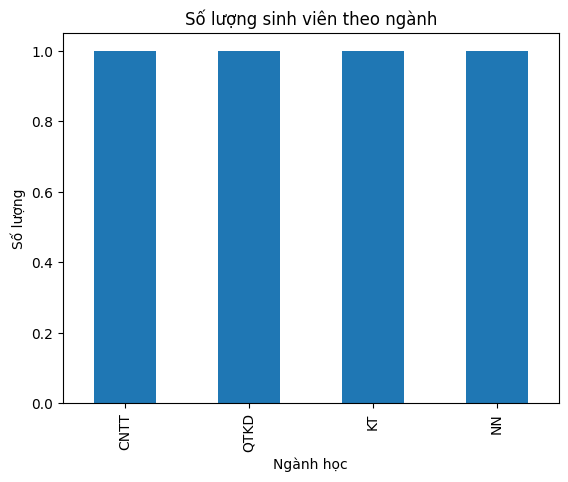

```python
# Đọc file, lấy HoTen làm index
d = pd.read_csv("sinhvien.csv", index_col=0)

# Đếm số sinh viên theo ngành
count_nganh = d["Nganh"].value_counts()

# Vẽ biểu đồ cột
count_nganh.plot(kind="bar")
plt.title("Số lượng sinh viên theo ngành")
plt.xlabel("Ngành học")
plt.ylabel("Số lượng")
plt.show()
```

```python
# Truy cập vào từng ô trong dataframe
d = pd.read_csv("sinhvien.csv", index_col=0)
print(d)
```

```
        Tuoi Nganh
HoTen
Thuong    20  CNTT
Anh       22  QTKD
Nhat      21    KT
Duy       23    NN
```

```python
# Xóa dòng hoặc cột
print(d.drop("Duy")) # xóa dòng có index là Duy
print(d.drop("Nganh", axis=1)) # xóa cột Ngành
```

```
        Tuoi Nganh
HoTen
Thuong    20  CNTT
Anh       22  QTKD
Nhat      21    KT
        Tuoi
HoTen
Thuong    20
Anh       22
Nhat      21
Duy       23
```

### 19. Làm việc với panel

```python
import pandas as pd
import numpy as np
```

```python
data = np.random.rand(2, 3, 4)
print("Mảng NumPy 3D:")
print(data)
```

```
Mảng NumPy 3D:
[[[0.65381685 0.688615   0.17157564 0.88593246]
  [0.34402736 0.44405836 0.45711149 0.66782698]
  [0.54995687 0.56118679 0.62987838 0.85953125]]

 [[0.00408941 0.19643527 0.85828426 0.29278464]
  [0.14911202 0.87909091 0.88115948 0.20170803]
  [0.82313156 0.6594127  0.37886752 0.4337783 ]]]
```

### 20. Chọn và nhóm phần tử

> Nhóm phần tử

```python
df2 = pd.DataFrame({'X' : ['B', 'B', 'A', 'A'], 'Y' : [1, 2, 3, 4]})
df2.groupby(['X']).sum()
```

| X | Y |
| --- | --- |
| A | 7 |
| B | 3 |

```python
#Nhóm phần tử
df2.groupby(['X'], sort=False).sum()
```

| X | Y |
| --- | --- |
| B | 3 |
| A | 7 |

```python
#Nhóm phầm tử
df3 = pd.DataFrame({'X' : ['A', 'B', 'A', 'B'], 'Y' :
[1, 4, 3, 2]})
df3.groupby(['X']).get_group('A')
```

|  | X | Y |
| --- | --- | --- |
| 0 | A | 1 |
| 2 | A | 3 |

```python
# Nhóm phần tử
df3.groupby(['X']).get_group('B')
```

|  | X | Y |
| --- | --- | --- |
| 1 | B | 4 |
| 3 | B | 2 |

### 21. Sử dụng pandas trong bài toán thực tế

> Đọc và tiền xử lý dữ liệu

```python
import matplotlib.pyplot as plt
import pandas as pd
import numpy as np

# đọc dữ liệu từ file csv, chuyển dữ liệu cột 1 sang date
df = pd.read_csv("kqsx.csv", index_col = 0, parse_dates=True)

# xóa bỏ các dòng không có dữ liệu
df.dropna(inplace=True)
# thêm cột mới là 2 số cuối của giải độc đắc
df['Cuoi'] = df.So % 100
```

> Khảo sát dữ liệu

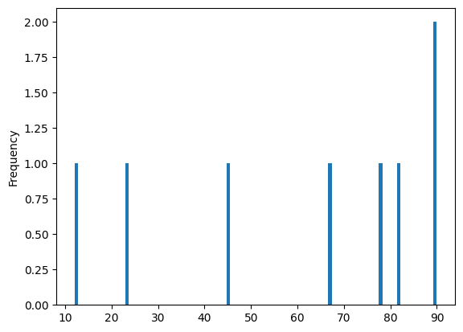

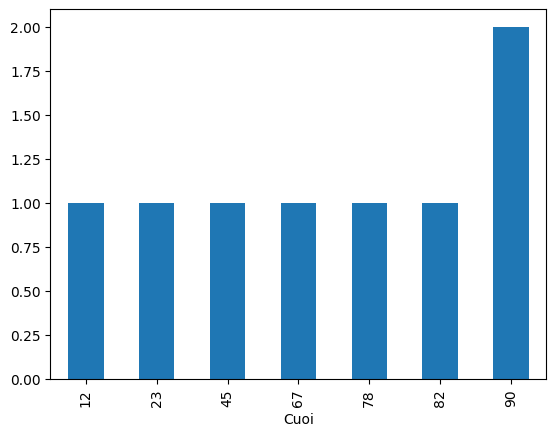

```python
# trích xuất cột mới thành dữ liệu series để dễ xử lý
s = pd.Series(df["Cuoi"], dtype="int64")

# xem phân bổ dữ liệu: biểu đồ histogram, 100 nhóm
s.plot(kind="hist", bins=100)
plt.show()

# một dạng phân bổ dữ liệu khác: biểu đồ bar, đếm tần suất
s.value_counts().sort_index().plot(kind="bar")
plt.show()
```

> Viết hàm tính số tiền thu về

```python
# thử bộ số myNums, kết quả về là result, số tiền chơi là money
def one_day(myNums, result, money):
    pay = len(myNums) * money
    get = money * 70 if result in myNums else 0
    return get - pay

# chơi nhiều ngày bộ số myNums, kết quả về là results
def many_day(myNums, results, money):
    total = 0
    for x in results:
        total += one_day(myNums, x, money)
    return total
```

> Chiến lược nuôi một số

```python
money = 1000

# thử chiến lược chơi: nuôi một con
print("Chơi con 76 toàn năm 2000:", many_day([76], s[0:367], money))
print("Chơi con 76 toàn bộ các năm:", many_day([76], s, money))
# thử chiến lược chơi: nuôi nhiều con
print("Nuôi nhiều số toàn năm 2000:", many_day([76, 92, 3, 10, 51, 45], s[0:367], money))
print("Nuôi nhiều số toàn bộ các năm:", many_day([76, 92, 3, 10, 51,45], s, money))
```

```
Chơi con 76 toàn năm 2000: -8000
Chơi con 76 toàn bộ các năm: -8000
Nuôi nhiều số toàn năm 2000: 22000
Nuôi nhiều số toàn bộ các năm: 22000
```

> Chiến lược: thống kê

```python
# thống kê con ra nhiều nhất rồi chơi

x = s[0:362].value_counts().idxmax()
y = s.value_counts().idxmax()
print("Chơi theo số ra nhiều nhất năm 2000:", x,
many_day([x], s, money))
print("Chơi theo số ra nhiều nhất các năm:", y,
many_day([y], s, money))
```

```
Chơi theo số ra nhiều nhất năm 2000: 90 132000
Chơi theo số ra nhiều nhất các năm: 90 132000
```

> Chiến lược: ngẫu nhiên

```python
# chơi ngẫu nhiên, mỗi ngày một con

total = 0
for d in s:
 total -= money
m = np.random.randint(100)
if (m == d): total += 70 * money
print("Chơi ngẫu nhiên:", total)
```

```
Chơi ngẫu nhiên: -8000
```

### 22. Thư viện scikit-learn

#### 22.1. Một số loại bài toán học máy

- Hệ thống phân loại email
- Nhận dạng chữ viết từ ảnh
- Ước lượng giá cả của sản phẩm
- Dự báo thời tiết
- Đánh giá trạng thái của người qua ảnh/video
- Trả lời tự động (chat bot)
- Gợi ý sản phẩm phù hợp với nhu cầu khách hàng
- Tự động chơi trò chơi
- Mô phỏng giọng nói của một người nào đó

#### 22.2. Dự báo sử dụng hồi quy tuyến tính

```python
import matplotlib.pyplot as plt
import pandas as pd
import numpy as np
from sklearn import linear_model, metrics
```

```
     Cao  Nang
Ten
A    147    49
B    150    50
C    153    51
D    155    51
E    168    60
F    170    62
G    173    68
H    175    65
I    178    66
J    180    71
K    183    68
L    165    59
M    163    58
N    160    56
O    158    54
P    169    62
Q    172    63
S    170    62
T    176    62
U    180    69
```

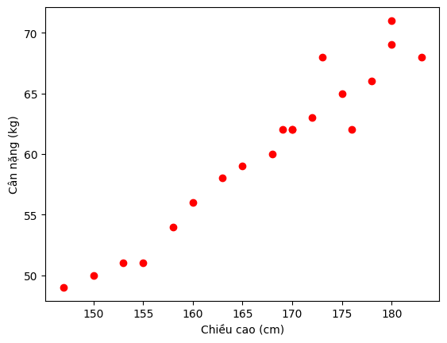

```
Tổng bình phương sai số trên tập mẫu: 2.546685519029107
Hệ số hồi quy: [0.61529398]
Sai số: -42.607917992223435
Công thức: [Nặng] = [0.61529398] x [Cao] +-42.607917992223435
```

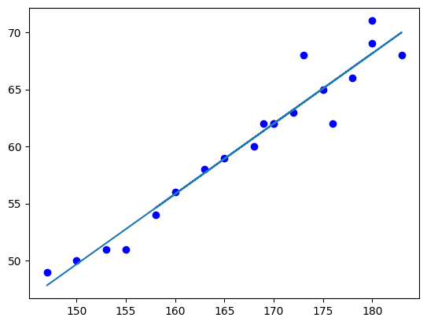

```python
# đọc dữ liệu từ file csv
df = pd.read_csv("nguoi.csv", index_col = 0)
print(df)
# vẽ biểu đồ minh họa dataset
plt.plot(df.Cao, df.Nang, 'ro')
plt.xlabel('Chiều cao (cm)')
plt.ylabel('Cân nặng (kg)')
plt.show()
# sử dụng hồi quy tuyến tính
X = df.loc[:, ['Cao']].values
y = df.Nang.values

# X là dữ liệu đầu vào
# y là dữ liệu đầu ra
# loại mô hình
# tập huấn trên dữ liệu

model = linear_model.LinearRegression()
model.fit(X, y)
# in một số thông tin về mô hình
mse = metrics.mean_squared_error(model.predict(X), y)
print("Tổng bình phương sai số trên tập mẫu:", mse)
print("Hệ số hồi quy:", model.coef_)
print("Sai số:", model.intercept_)
print(f"Công thức: [Nặng] = {model.coef_} x [Cao] +{model.intercept_}")
# vẽ lại sơ đồ
plt.scatter(X, y, c='b')
plt.plot(X, model.predict(X))
plt.show()

# dự báo một số tình huống
while True:

 x = float(input("Nhập chiều cao (nhập 0 để dừng): "))
 if x <= 0: break
 print("Người cao", x, "cm, dự báo cân nặng",

model.predict([[x]]))
```

```python
# Mở rộng mô hình (thêm cột giới tính)
import matplotlib.pyplot as plt
import pandas as pd
import numpy as np
from sklearn import linear_model, metrics
```

```python
# đọc dữ liệu từ file csv
df = pd.read_csv("nguoi2.csv", index_col = 0)
print(df)
# thêm cột mới, giới tính Nam = 1, giới tính Nữ = 0
df['GT'] = df.Gioitinh.apply(lambda x: 1 if x=='Nam' else 0)
print(df)
# sử dụng hồi quy tuyến tính
X = df.loc[:, ['Cao', 'GT']].values
y = df.Nang.values

# X là dữ liệu đầu vào
# y là dữ liệu đầu ra
model = linear_model.LinearRegression() # loại mô hình
model.fit(X, y) # tập huấn trên dữ liệu

# in một số thông tin về mô hình
mse = metrics.mean_squared_error(model.predict(X), y)
print("Tổng bình phương sai số trên tập mẫu:", mse)
print("Hệ số hồi quy:", model.coef_)
print("Sai số:", model.intercept_)
print(f"Công thức: [Nặng] = {model.coef_} x [Cao, Giới tính] + {model.intercept_}")

# dự báo một số tình huống
while True:

 x = float(input("Nhập chiều cao (nhập 0 để dừng): "))
 if x <= 0: break
 print("Nam giới cao", x, "cm, dự báo cân nặng",

 model.predict([[x, 1]]))

 print("Nữ giới cao", x, "cm, dự báo cân nặng",

 model.predict([[x, 0]]))
```

```
    Gioitinh  Cao  Nang
Ten
A         Nu  147    49
B         Nu  150    50
C         Nu  153    51
D        Nam  155    51
E        Nam  168    60
F         Nu  170    62
G         Nu  173    68
H         Nu  175    65
I        Nam  178    66
J        Nam  180    71
K        Nam  183    68
L        Nam  165    59
M        Nam  163    58
N         Nu  160    56
O         Nu  158    54
P        Nam  169    62
Q        Nam  172    63
S         Nu  170    62
T        Nam  176    62
U        Nam  180    69
    Gioitinh  Cao  Nang  GT
Ten
A         Nu  147    49   0
B         Nu  150    50   0
C         Nu  153    51   0
D        Nam  155    51   1
E        Nam  168    60   1
F         Nu  170    62   0
G         Nu  173    68   0
H         Nu  175    65   0
I        Nam  178    66   1
J        Nam  180    71   1
K        Nam  183    68   1
L        Nam  165    59   1
M        Nam  163    58   1
N         Nu  160    56   0
O         Nu  158    54   0
P        Nam  169    62   1
Q        Nam  172    63   1
S         Nu  170    62   0
T        Nam  176    62   1
U        Nam  180    69   1
Tổng bình phương sai số trên tập mẫu: 2.2683723118445966
Hệ số hồi quy: [ 0.6433621  -1.20920875]
Sai số: -46.63724604127721
Công thức: [Nặng] = [ 0.6433621  -1.20920875] x [Cao, Giới tính] + -46.63724604127721
Nam giới cao 175.0 cm, dự báo cân nặng [64.74191232]
Nữ giới cao 175.0 cm, dự báo cân nặng [65.95112107]
```

## Kết thúc

```python
!jupyter nbconvert --to html "PNMP.ipynb"
```

```
[NbConvertApp] Converting notebook PNMP.ipynb to html
[NbConvertApp] WARNING | Alternative text is missing on 17 image(s).
[NbConvertApp] Writing 1153370 bytes to PNMP.html
```